# Predict Taxi Fares with Random Forests

## Predicting taxi fares using a tree

The map from the previous task showed that the journeys are highly concentrated in the business and tourist areas. We also see that some taxi trips originating in Brooklyn slipped through, but that’s fine.

We’re now going to use a regression tree to predict the total fare with lat and long being the predictors. The tree algorithm will try to find cutpoints in those predictors that results in the decision tree with the best predictive capability.

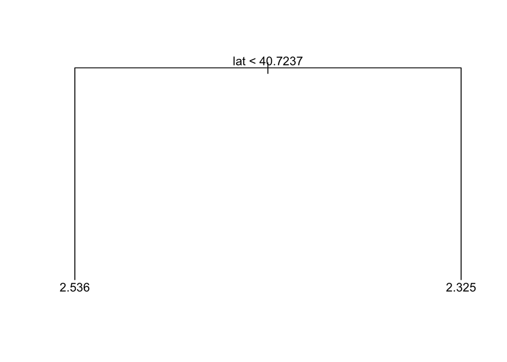

```r
# Loading in the tree package
# .... YOUR CODE FOR TASK 5 HERE ....
library(tree)

# Fitting a tree to lat and long
fitted_tree <- tree(total~lat+long, data = taxi)

# Draw a diagram of the tree structure
# .... YOUR CODE FOR TASK 5 HERE ....
plot(fitted_tree)
text(fitted_tree)
```

```r
summary(fitted_tree)
```

```
##
## Regression tree:
## tree(formula = total ~ lat + long, data = taxi)
## Variables actually used in tree construction:
## [1] "lat"
## Number of terminal nodes:  2
## Residual mean deviance:  0.3041 = 13910 / 45760
## Distribution of residuals:
##     Min.  1st Qu.   Median     Mean  3rd Qu.     Max.
## -1.61900 -0.37880 -0.04244  0.00000  0.32660  2.69900
```

## It’s time. More predictors.

The tree above looks a bit frugal, it only includes one split: It predicts that trips where lat < 40.7237 are more expensive, which makes sense as it is downtown Manhattan. But that’s it. It didn’t even include long as tree deemed that it didn’t improve the predictions. Taxi drivers will need more information than this and any driver paying for your data-driven insights would be disappointed with that. As we know from Robert de Niro, it’s best not to upset New York taxi drivers.

Let’s start by adding some more predictors related to the time the taxi trip was made.

```r
# Loading in the lubridate package
# .... YOUR CODE FOR TASK 6 HERE ....
library(lubridate)
# Generate the three new time variables
taxi <- taxi %>%
    mutate(hour = hour(pickup_datetime),  wday = wday(pickup_datetime, label = TRUE),
           month = month(pickup_datetime, label = TRUE))
```

## One more tree!

Let’s try fitting a new regression tree where we include the new time variables.

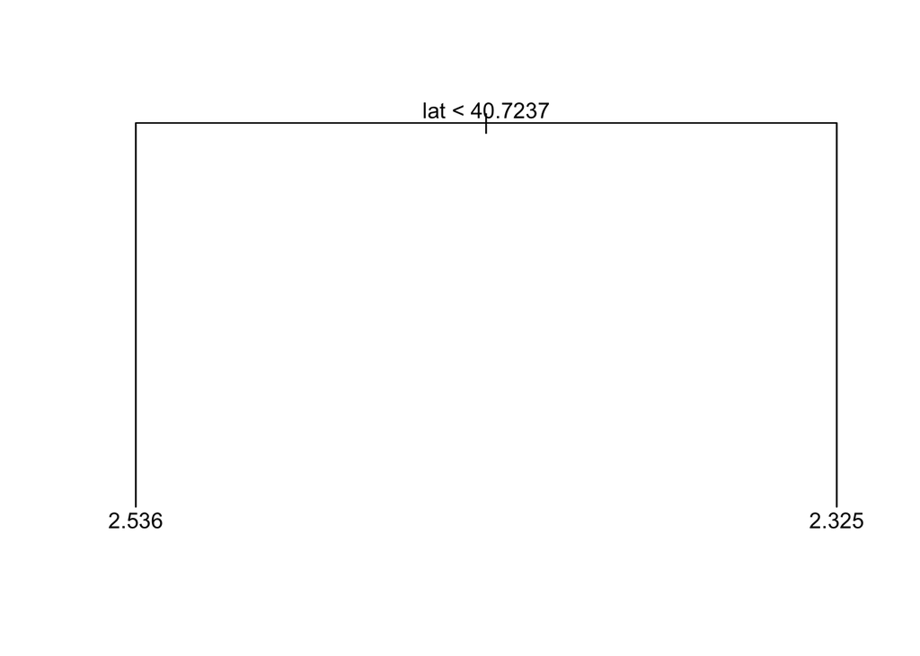

```r
# Fitting a tree with total as the outcome and
# lat, long, hour, wday, and month as predictors
fitted_tree <- tree(total~lat+long+hour+wday+month, data = taxi)

# draw a diagram of the tree structure
# .... YOUR CODE FOR TASK 7 HERE ....
plot(fitted_tree)

# Summarizing the performance of the tree
# .... YOUR CODE FOR TASK 7 HERE ....
text(fitted_tree)
```

```r
summary(fitted_tree)
```

```
##
## Regression tree:
## tree(formula = total ~ lat + long + hour + wday + month, data = taxi)
## Variables actually used in tree construction:
## [1] "lat"
## Number of terminal nodes:  2
## Residual mean deviance:  0.3041 = 13910 / 45760
## Distribution of residuals:
##     Min.  1st Qu.   Median     Mean  3rd Qu.     Max.
## -1.61900 -0.37880 -0.04244  0.00000  0.32660  2.69900
```

8. One tree is not enough The regression tree has not changed after including the three time variables. This is likely because latitude is still the most promising first variable to split the data on, and after that split, the other variables are not informative enough to be included. A random forest model, where many different trees are fitted to subsets of the data, may well include the other variables in some of the trees that make it up.

```r
# Loading in the randomForest package
# .... YOUR CODE FOR TASK 8 HERE ....
library(randomForest)
```

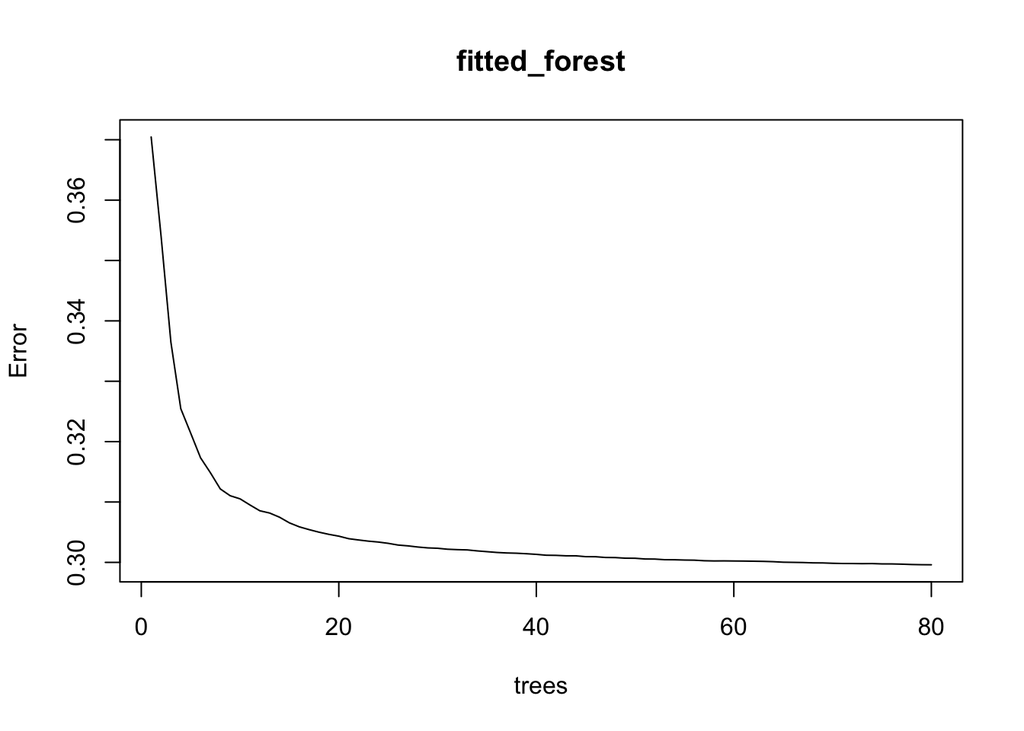

```r
# Fitting a random forest
fitted_forest <- randomForest(total~long+lat+hour+wday+month, data = taxi, ntree = 80, sampsize = 10000)

# Printing the fitted_forest object
# .... YOUR CODE FOR TASK 8 HERE ....
plot(fitted_forest)
```

```r
summary(fitted_forest)
```

```
##                 Length Class  Mode
## call                5  -none- call
## type                1  -none- character
## predicted       45766  -none- numeric
## mse                80  -none- numeric
## rsq                80  -none- numeric
## oob.times       45766  -none- numeric
## importance          5  -none- numeric
## importanceSD        0  -none- NULL
## localImportance     0  -none- NULL
## proximity           0  -none- NULL
## ntree               1  -none- numeric
## mtry                1  -none- numeric
## forest             11  -none- list
## coefs               0  -none- NULL
## y               45766  -none- numeric
## test                0  -none- NULL
## inbag               0  -none- NULL
## terms               3  terms  call
```

## Plotting the predicted fare

Now, let’s take a look at the predictions of fitted_forest projected back onto Manhattan.

[figure not shown]

```r
# Extracting the prediction from fitted_forest
taxi$pred_total <- fitted_forest$predicted

# Plotting the predicted mean trip prices from according to the random forest
# .... COPY CODE FROM TASK 4 AND MODIFY HERE ....
# Drawing a density map with the number of journey start locations
ggmap(manhattan, darken = 0.5) +
   scale_fill_viridis(option = 'plasma') +
   # .... YOUR CODE FOR TASK 4 ....
   stat_summary_2d(data = taxi, aes(x = long, y = lat, z = pred_total), fun = mean, alpha =  0.6, bins = 60) +
  labs(x="Longitude", y="Latitude", fill="Error")
```

## Plotting the actual fare

Looking at the map with the predicted fares we see that fares in downtown Manhattan are predicted to be high, while midtown is lower. This map only shows the prediction as a function of lat and long, but we could also plot the predictions over time, or a combination of time and space, but we’ll leave that for another time.

For now, let’s compare the map with the predicted fares with a new map showing the mean fares according to the data.

[figure not shown]

```r
# Function that returns the mean *if* there are 15 or more datapoints
mean_if_enough_data <- function(x) {
    ifelse( length(x) >= 15, mean(x), NA)
}

# Plotting the mean trip prices from the data
# .... COPY CODE FROM TASK 9 AND MODIFY HERE ....
ggmap(manhattan, darken = 0.5) +
   scale_fill_viridis(option = 'plasma') +
   # .... YOUR CODE FOR TASK 4 ....
   stat_summary_2d(data = taxi, aes(x = long, y = lat, z = total), fun = mean_if_enough_data, alpha =  0.6, bins = 60) +
  labs(x="Longitude", y="Latitude", fill="Error")
```

## Where do people spend the most?

So it looks like the random forest model captured some of the patterns in our data. At this point in the analysis, there are many more things we could do that we haven’t done. We could add more predictors if we have the data. We could try to fine-tune the parameters of randomForest. And we should definitely test the model on a hold-out test dataset. But for now, let’s be happy with what we have achieved!

So, if you are a taxi driver in NYC, where in Manhattan would you expect people to spend the most on a taxi ride?

```r
# Where are people spending the most on their taxi trips?
spends_most_on_trips <- "downtown" # "uptown" or "downtown"
```